# DATA621 - Insurance

#### MODEL 2.

MLR Full model with log transformation on amt, all variables, amt only

```r
training_target_amt$TARGET_AMT <- log(training_target_amt$TARGET_AMT)
target_amt_model_all <- glm(TARGET_AMT~.,data=training_target_amt[,c(inputs,target_lm)])
summary(target_amt_model_all)
```

```
##
## Call:
## glm(formula = TARGET_AMT ~ ., data = training_target_amt[, c(inputs,
##     target_lm)])
##
## Deviance Residuals:
##     Min       1Q   Median       3Q      Max
## -4.6590  -0.4065   0.0362   0.4114   3.2775
##
## Coefficients:
##                        Estimate Std. Error t value Pr(>|t|)
## (Intercept)           7.885e+00  2.108e-01  37.402  < 2e-16 ***
## PARENT1_BIN           2.580e-02  6.187e-02   0.417 0.676662
## NON_HOMEOWNER_BIN    -2.968e-02  4.650e-02  -0.638 0.523386
## IS_SINGLE_BIN         9.331e-02  5.268e-02   1.771 0.076690 .
## IS_MALE_BIN           9.370e-02  6.886e-02   1.361 0.173723
## ED_HS_BIN             7.738e-03  5.403e-02   0.143 0.886132
## ED_BACHELORS_BIN     -2.683e-02  6.759e-02  -0.397 0.691487
## ED_MASTERS_BIN        1.560e-01  1.141e-01   1.368 0.171603
## ED_PHD_BIN            2.553e-01  1.367e-01   1.868 0.061936 .
## JOB_BLUE_COLLAR_BIN   6.405e-02  1.203e-01   0.533 0.594336
## JOB_CLERICAL_BIN      5.322e-02  1.263e-01   0.422 0.673421
## JOB_PROFESSIONAL_BIN  1.089e-01  1.185e-01   0.919 0.358127
## JOB_MANAGERIAL_BIN    2.147e-02  1.120e-01   0.192 0.847998
## JOB_LAWYER_BIN       -1.084e-02  1.081e-01  -0.100 0.920110
## JOB_STUDENT_BIN       4.543e-02  1.342e-01   0.339 0.734959
## JOB_DOCTOR_BIN       -2.927e-02  1.855e-01  -0.158 0.874673
## JOB_HOME_MAKER_BIN   -3.033e-02  1.294e-01  -0.234 0.814712
## IS_COMMERCIAL_BIN     1.415e-02  5.488e-02   0.258 0.796551
## CAR_PANEL_TRUCK_BIN  -2.814e-03  1.005e-01  -0.028 0.977664
## CAR_PICKUP_BIN        2.678e-02  6.277e-02   0.427 0.669627
## CAR_SPORTS_CAR_BIN    5.738e-02  7.882e-02   0.728 0.466746
## CAR_VAN_BIN          -1.563e-02  8.110e-02  -0.193 0.847171
## CAR_SUV_BIN           9.287e-02  7.003e-02   1.326 0.184978
## RED_CAR_BIN           2.248e-02  5.220e-02   0.431 0.666720
## REVOKED_BIN          -9.881e-02  5.472e-02  -1.806 0.071098 .
## IS_URBAN_BIN          5.631e-02  7.945e-02   0.709 0.478602
## AGE                   2.270e-03  2.241e-03   1.013 0.311169
## YOJ                  -4.977e-03  5.358e-03  -0.929 0.353098
## CAR_AGE              -2.420e-03  4.655e-03  -0.520 0.603255
## KIDSDRIV             -3.476e-02  3.344e-02  -1.039 0.298764
## HOMEKIDS              2.626e-02  2.203e-02   1.192 0.233437
## TRAVTIME             -3.735e-04  1.172e-03  -0.319 0.750069
## TIF                  -2.080e-03  4.501e-03  -0.462 0.644061
## CLM_FREQ             -3.830e-02  1.691e-02  -2.265 0.023610 *
## MVR_PTS               1.547e-02  7.285e-03   2.124 0.033815 *
## INCOME               -1.353e-06  7.091e-07  -1.908 0.056496 .
## BLUEBOOK              1.256e-05  3.248e-06   3.865 0.000114 ***
## OLDCLAIM              4.957e-06  2.515e-06   1.971 0.048871 *
## ---
## Signif. codes:  0 '***' 0.001 '**' 0.01 '*' 0.05 '.' 0.1 ' ' 1
##
## (Dispersion parameter for gaussian family taken to be 0.6534742)
##
##     Null deviance: 1420.9  on 2152  degrees of freedom
## Residual deviance: 1382.1  on 2115  degrees of freedom
## AIC: 5233.6
##
## Number of Fisher Scoring iterations: 2
```

```r
model2_amt <- target_amt_model_all
```

#### Model 3.

Manually remove variables from model 1 that weren’t significant for flag. And try a version for amt that only has a few variables.

```r
inputs_manual_amt <- inputs[c(4,24,28,36)]
training_target_amt <- training_trans[training_trans$TARGET_FLAG==1,]
target_amt_model_all <- glm(TARGET_AMT~.,data=training_target_amt[,c(inputs_manual_amt,target_lm)])
summary(target_amt_model_all)
```

```
##
## Call:
## glm(formula = TARGET_AMT ~ ., data = training_target_amt[, c(inputs_manual_amt,
##     target_lm)])
##
## Deviance Residuals:
##    Min      1Q  Median      3Q     Max
##  -7862   -3157   -1586     406  100731
##
## Coefficients:
##               Estimate Std. Error t value Pr(>|t|)
## (Intercept) 4273.32491  411.40245  10.387  < 2e-16 ***
## IS_MALE_BIN  620.02474  334.50432   1.854   0.0639 .
## REVOKED_BIN -682.52623  409.37892  -1.667   0.0956 .
## CAR_AGE      -48.79218   31.70237  -1.539   0.1239
## BLUEBOOK       0.11641    0.02079   5.601 2.41e-08 ***
## ---
## Signif. codes:  0 '***' 0.001 '**' 0.01 '*' 0.05 '.' 0.1 ' ' 1
##
## (Dispersion parameter for gaussian family taken to be 58959010)
##
##     Null deviance: 1.2903e+11  on 2152  degrees of freedom
## Residual deviance: 1.2664e+11  on 2148  degrees of freedom
## AIC: 44639
##
## Number of Fisher Scoring iterations: 2
```

```r
model3_amt = target_amt_model_all
```

#### Model 4.

Binary Logistic Regression Baseline with all variables.

```r
training_target_flag <- training_trans_model_bin
target_flag_model_all <- glm(TARGET_FLAG~.,data=training_target_flag[,c(inputs,target_bin)],family = binomial(link = "logit"))
summary(target_flag_model_all)
```

```
##
## Call:
## glm(formula = TARGET_FLAG ~ ., family = binomial(link = "logit"),
##     data = training_target_flag[, c(inputs, target_bin)])
##
## Deviance Residuals:
##     Min       1Q   Median       3Q      Max
## -2.3581  -0.7065  -0.3986   0.6012   3.1550
##
## Coefficients:
##                        Estimate Std. Error z value Pr(>|z|)
## (Intercept)          -4.468e+00  4.107e-01 -10.879  < 2e-16 ***
## PARENT1_BIN           4.551e-01  1.308e-01   3.479 0.000503 ***
## NON_HOMEOWNER_BIN     2.946e-01  9.145e-02   3.221 0.001278 **
## IS_SINGLE_BIN         4.907e-01  9.929e-02   4.942 7.74e-07 ***
## IS_MALE_BIN           1.650e-01  1.343e-01   1.228 0.219397
## ED_HS_BIN             3.281e-02  1.139e-01   0.288 0.773324
## ED_BACHELORS_BIN     -3.868e-01  1.385e-01  -2.792 0.005237 **
## ED_MASTERS_BIN       -2.185e-01  2.157e-01  -1.013 0.310938
## ED_PHD_BIN           -2.105e-01  2.549e-01  -0.826 0.408897
## JOB_BLUE_COLLAR_BIN   3.772e-01  2.203e-01   1.713 0.086751 .
## JOB_CLERICAL_BIN      5.316e-01  2.339e-01   2.272 0.023078 *
## JOB_PROFESSIONAL_BIN  1.868e-01  2.115e-01   0.883 0.377146
## JOB_MANAGERIAL_BIN   -6.259e-01  2.040e-01  -3.069 0.002150 **
## JOB_LAWYER_BIN        4.424e-02  2.029e-01   0.218 0.827373
## JOB_STUDENT_BIN       4.521e-01  2.544e-01   1.777 0.075511 .
## JOB_DOCTOR_BIN       -4.271e-01  3.127e-01  -1.366 0.171966
## JOB_HOME_MAKER_BIN    5.548e-01  2.436e-01   2.278 0.022747 *
## IS_COMMERCIAL_BIN     8.014e-01  1.091e-01   7.343 2.09e-13 ***
## CAR_PANEL_TRUCK_BIN   5.760e-01  1.941e-01   2.967 0.003009 **
## CAR_PICKUP_BIN        5.838e-01  1.216e-01   4.802 1.57e-06 ***
## CAR_SPORTS_CAR_BIN    9.726e-01  1.579e-01   6.158 7.35e-10 ***
## CAR_VAN_BIN           7.756e-01  1.504e-01   5.157 2.51e-07 ***
## CAR_SUV_BIN           7.398e-01  1.346e-01   5.498 3.85e-08 ***
## RED_CAR_BIN          -1.478e-01  1.036e-01  -1.427 0.153499
## REVOKED_BIN           8.628e-01  1.098e-01   7.860 3.85e-15 ***
## IS_URBAN_BIN          2.330e+00  1.314e-01  17.734  < 2e-16 ***
## AGE                   3.291e-03  4.899e-03   0.672 0.501779
## YOJ                  -1.910e-02  1.048e-02  -1.822 0.068506 .
## CAR_AGE              -1.102e-03  9.131e-03  -0.121 0.903942
## KIDSDRIV              3.744e-01  7.463e-02   5.018 5.23e-07 ***
## HOMEKIDS              5.173e-02  4.505e-02   1.148 0.250872
## TRAVTIME              1.457e-02  2.320e-03   6.280 3.39e-10 ***
## TIF                  -6.638e-02  9.018e-03  -7.361 1.83e-13 ***
## CLM_FREQ              1.920e-01  3.471e-02   5.530 3.20e-08 ***
## MVR_PTS               1.112e-01  1.638e-02   6.789 1.13e-11 ***
## INCOME               -2.903e-06  1.265e-06  -2.295 0.021747 *
## BLUEBOOK             -2.831e-05  6.430e-06  -4.402 1.07e-05 ***
## OLDCLAIM             -1.155e-05  4.927e-06  -2.344 0.019099 *
## ---
## Signif. codes:  0 '***' 0.001 '**' 0.01 '*' 0.05 '.' 0.1 ' ' 1
##
## (Dispersion parameter for binomial family taken to be 1)
##
##     Null deviance: 6592.6  on 5712  degrees of freedom
## Residual deviance: 5088.3  on 5675  degrees of freedom
## AIC: 5164.3
##
## Number of Fisher Scoring iterations: 5
```

```r
model4_flag = target_flag_model_all
```

#### Model 5.

```r
inputs_manual_flag <- inputs[-c(4,5,8,9,11,13,14,15,23,26,28,30)]
target_flag_model_all <- glm(TARGET_FLAG~.,data=training_target_flag[,c(inputs_manual_flag,target_bin)],family = binomial(link = "logit"))
summary(target_flag_model_all)
```

```
##
## Call:
## glm(formula = TARGET_FLAG ~ ., family = binomial(link = "logit"),
##     data = training_target_flag[, c(inputs_manual_flag, target_bin)])
##
## Deviance Residuals:
##     Min       1Q   Median       3Q      Max
## -2.4508  -0.7123  -0.4049   0.6065   3.1209
##
## Coefficients:
##                       Estimate Std. Error z value Pr(>|z|)
## (Intercept)         -3.735e+00  2.342e-01 -15.949  < 2e-16 ***
## PARENT1_BIN          5.386e-01  1.126e-01   4.783 1.73e-06 ***
## NON_HOMEOWNER_BIN    3.193e-01  8.611e-02   3.708 0.000209 ***
## IS_SINGLE_BIN        4.139e-01  9.298e-02   4.451 8.53e-06 ***
## ED_BACHELORS_BIN    -3.391e-01  8.551e-02  -3.966 7.32e-05 ***
## ED_MASTERS_BIN      -2.944e-01  1.024e-01  -2.875 0.004037 **
## JOB_CLERICAL_BIN     2.597e-01  1.102e-01   2.357 0.018445 *
## JOB_MANAGERIAL_BIN  -8.072e-01  1.312e-01  -6.153 7.60e-10 ***
## JOB_HOME_MAKER_BIN   2.539e-01  1.450e-01   1.751 0.080006 .
## IS_COMMERCIAL_BIN    9.367e-01  8.996e-02  10.413  < 2e-16 ***
## CAR_PANEL_TRUCK_BIN  5.189e-01  1.713e-01   3.030 0.002444 **
## CAR_PICKUP_BIN       5.200e-01  1.187e-01   4.379 1.19e-05 ***
## CAR_SPORTS_CAR_BIN   9.238e-01  1.309e-01   7.057 1.70e-12 ***
## CAR_VAN_BIN          7.226e-01  1.419e-01   5.093 3.52e-07 ***
## CAR_SUV_BIN          6.870e-01  1.030e-01   6.669 2.58e-11 ***
## REVOKED_BIN          8.725e-01  1.092e-01   7.990 1.35e-15 ***
## IS_URBAN_BIN         2.293e+00  1.308e-01  17.529  < 2e-16 ***
## YOJ                 -2.477e-02  9.456e-03  -2.619 0.008810 **
## KIDSDRIV             4.287e-01  6.661e-02   6.435 1.23e-10 ***
## TRAVTIME             1.479e-02  2.313e-03   6.396 1.59e-10 ***
## TIF                 -6.620e-02  8.995e-03  -7.360 1.84e-13 ***
## CLM_FREQ             1.885e-01  3.452e-02   5.461 4.74e-08 ***
## MVR_PTS              1.092e-01  1.630e-02   6.703 2.04e-11 ***
## INCOME              -5.506e-06  1.073e-06  -5.133 2.85e-07 ***
## BLUEBOOK            -3.154e-05  5.743e-06  -5.491 4.00e-08 ***
## OLDCLAIM            -1.139e-05  4.903e-06  -2.323 0.020190 *
## ---
## Signif. codes:  0 '***' 0.001 '**' 0.01 '*' 0.05 '.' 0.1 ' ' 1
##
## (Dispersion parameter for binomial family taken to be 1)
##
##     Null deviance: 6592.6  on 5712  degrees of freedom
## Residual deviance: 5113.7  on 5687  degrees of freedom
## AIC: 5165.7
##
## Number of Fisher Scoring iterations: 5
```

```r
model5_flag = target_flag_model_all
```

#### Model 6.

```r
stepwise_flag_model <- glm(TARGET_FLAG~.,data=training_target_flag[,c(inputs,target_bin)], family = binomial(link = "probit"))

backward <- step(stepwise_flag_model, trace = 0)
predict2 <- round(predict(backward, type = 'response'), 4)
summary(backward)
```

```
##
## Call:
## glm(formula = TARGET_FLAG ~ PARENT1_BIN + NON_HOMEOWNER_BIN +
##     IS_SINGLE_BIN + ED_BACHELORS_BIN + ED_MASTERS_BIN + ED_PHD_BIN +
##     JOB_BLUE_COLLAR_BIN + JOB_CLERICAL_BIN + JOB_MANAGERIAL_BIN +
##     JOB_STUDENT_BIN + JOB_DOCTOR_BIN + JOB_HOME_MAKER_BIN + IS_COMMERCIAL_BIN +
##     CAR_PANEL_TRUCK_BIN + CAR_PICKUP_BIN + CAR_SPORTS_CAR_BIN +
##     CAR_VAN_BIN + CAR_SUV_BIN + REVOKED_BIN + IS_URBAN_BIN +
##     YOJ + KIDSDRIV + TRAVTIME + TIF + CLM_FREQ + MVR_PTS + INCOME +
##     BLUEBOOK + OLDCLAIM, family = binomial(link = "probit"),
##     data = training_target_flag[, c(inputs, target_bin)])
##
## Deviance Residuals:
##     Min       1Q   Median       3Q      Max
## -2.3892  -0.7268  -0.4010   0.6341   3.4713
##
## Coefficients:
##                       Estimate Std. Error z value Pr(>|z|)
## (Intercept)         -2.306e+00  1.526e-01 -15.114  < 2e-16 ***
## PARENT1_BIN          2.799e-01  6.604e-02   4.238 2.25e-05 ***
## NON_HOMEOWNER_BIN    1.654e-01  5.320e-02   3.110  0.00187 **
## IS_SINGLE_BIN        2.744e-01  5.544e-02   4.950 7.43e-07 ***
## ED_BACHELORS_BIN    -2.442e-01  5.627e-02  -4.340 1.43e-05 ***
## ED_MASTERS_BIN      -2.000e-01  7.886e-02  -2.536  0.01122 *
## ED_PHD_BIN          -2.065e-01  1.103e-01  -1.873  0.06111 .
## JOB_BLUE_COLLAR_BIN  1.246e-01  7.839e-02   1.589  0.11198
## JOB_CLERICAL_BIN     2.111e-01  8.308e-02   2.541  0.01106 *
## JOB_MANAGERIAL_BIN  -4.153e-01  7.667e-02  -5.417 6.08e-08 ***
## JOB_STUDENT_BIN      1.897e-01  1.032e-01   1.838  0.06612 .
## JOB_DOCTOR_BIN      -2.955e-01  1.618e-01  -1.826  0.06784 .
## JOB_HOME_MAKER_BIN   2.314e-01  9.744e-02   2.375  0.01755 *
## IS_COMMERCIAL_BIN    4.597e-01  5.822e-02   7.896 2.87e-15 ***
## CAR_PANEL_TRUCK_BIN  3.121e-01  1.015e-01   3.076  0.00209 **
## CAR_PICKUP_BIN       3.071e-01  6.878e-02   4.466 7.99e-06 ***
## CAR_SPORTS_CAR_BIN   5.201e-01  7.510e-02   6.925 4.35e-12 ***
## CAR_VAN_BIN          4.292e-01  8.255e-02   5.199 2.00e-07 ***
## CAR_SUV_BIN          3.909e-01  5.857e-02   6.673 2.50e-11 ***
## REVOKED_BIN          5.003e-01  6.388e-02   7.832 4.79e-15 ***
## IS_URBAN_BIN         1.283e+00  6.855e-02  18.711  < 2e-16 ***
## YOJ                 -8.908e-03  5.905e-03  -1.509  0.13141
## KIDSDRIV             2.411e-01  3.873e-02   6.225 4.81e-10 ***
## TRAVTIME             8.338e-03  1.329e-03   6.273 3.55e-10 ***
## TIF                 -3.804e-02  5.129e-03  -7.418 1.19e-13 ***
## CLM_FREQ             1.171e-01  2.035e-02   5.756 8.63e-09 ***
## MVR_PTS              6.438e-02  9.594e-03   6.711 1.94e-11 ***
## INCOME              -1.517e-06  7.153e-07  -2.121  0.03392 *
## BLUEBOOK            -1.689e-05  3.292e-06  -5.132 2.86e-07 ***
## OLDCLAIM            -6.712e-06  2.882e-06  -2.329  0.01987 *
## ---
## Signif. codes:  0 '***' 0.001 '**' 0.01 '*' 0.05 '.' 0.1 ' ' 1
##
## (Dispersion parameter for binomial family taken to be 1)
##
##     Null deviance: 6592.6  on 5712  degrees of freedom
## Residual deviance: 5101.5  on 5683  degrees of freedom
## AIC: 5161.5
##
## Number of Fisher Scoring iterations: 5
```

```r
model6_flag <- backward
```

```r
stepwise_flag_model2 <- glm(TARGET_FLAG~1,data=training_target_flag[,c(inputs,target_bin)], family = binomial(link = "probit"))

forward <- step(stepwise_flag_model2, scope = list(lower=formula(stepwise_flag_model2), upper=formula(stepwise_flag_model)), direction = "forward", trace = 0)
predict3 <- round(predict(forward, type = 'response'), 4)
summary(forward)
```

```
##
## Call:
## glm(formula = TARGET_FLAG ~ IS_URBAN_BIN + MVR_PTS + PARENT1_BIN +
##     IS_COMMERCIAL_BIN + BLUEBOOK + JOB_MANAGERIAL_BIN + REVOKED_BIN +
##     TIF + NON_HOMEOWNER_BIN + INCOME + TRAVTIME + KIDSDRIV +
##     CLM_FREQ + IS_SINGLE_BIN + ED_HS_BIN + CAR_SPORTS_CAR_BIN +
##     CAR_SUV_BIN + CAR_VAN_BIN + CAR_PICKUP_BIN + CAR_PANEL_TRUCK_BIN +
##     YOJ + JOB_CLERICAL_BIN + JOB_DOCTOR_BIN + OLDCLAIM + ED_BACHELORS_BIN +
##     ED_MASTERS_BIN + ED_PHD_BIN + JOB_HOME_MAKER_BIN, family = binomial(link = "probit"),
##     data = training_target_flag[, c(inputs, target_bin)])
##
## Deviance Residuals:
##     Min       1Q   Median       3Q      Max
## -2.4642  -0.7282  -0.4030   0.6292   3.4148
##
## Coefficients:
##                       Estimate Std. Error z value Pr(>|z|)
## (Intercept)         -2.156e+00  1.350e-01 -15.972  < 2e-16 ***
## IS_URBAN_BIN         1.274e+00  6.822e-02  18.674  < 2e-16 ***
## MVR_PTS              6.363e-02  9.580e-03   6.642 3.10e-11 ***
## PARENT1_BIN          2.850e-01  6.588e-02   4.325 1.52e-05 ***
## IS_COMMERCIAL_BIN    4.967e-01  5.460e-02   9.098  < 2e-16 ***
## BLUEBOOK            -1.734e-05  3.283e-06  -5.282 1.28e-07 ***
## JOB_MANAGERIAL_BIN  -4.605e-01  7.259e-02  -6.344 2.24e-10 ***
## REVOKED_BIN          4.972e-01  6.393e-02   7.777 7.40e-15 ***
## TIF                 -3.809e-02  5.127e-03  -7.429 1.09e-13 ***
## NON_HOMEOWNER_BIN    1.871e-01  5.016e-02   3.730 0.000191 ***
## INCOME              -1.764e-06  7.045e-07  -2.504 0.012296 *
## TRAVTIME             8.369e-03  1.329e-03   6.299 3.00e-10 ***
## KIDSDRIV             2.453e-01  3.866e-02   6.347 2.20e-10 ***
## CLM_FREQ             1.169e-01  2.034e-02   5.746 9.15e-09 ***
## IS_SINGLE_BIN        2.592e-01  5.391e-02   4.808 1.52e-06 ***
## ED_HS_BIN            8.826e-04  6.454e-02   0.014 0.989089
## CAR_SPORTS_CAR_BIN   5.216e-01  7.503e-02   6.952 3.61e-12 ***
## CAR_SUV_BIN          3.915e-01  5.854e-02   6.688 2.26e-11 ***
## CAR_VAN_BIN          4.123e-01  8.214e-02   5.020 5.17e-07 ***
## CAR_PICKUP_BIN       2.914e-01  6.834e-02   4.264 2.01e-05 ***
## CAR_PANEL_TRUCK_BIN  2.821e-01  9.955e-02   2.833 0.004606 **
## YOJ                 -1.141e-02  5.525e-03  -2.065 0.038889 *
## JOB_CLERICAL_BIN     1.115e-01  6.440e-02   1.731 0.083363 .
## JOB_DOCTOR_BIN      -3.035e-01  1.620e-01  -1.874 0.060998 .
## OLDCLAIM            -6.568e-06  2.880e-06  -2.281 0.022551 *
## ED_BACHELORS_BIN    -2.767e-01  7.031e-02  -3.936 8.29e-05 ***
## ED_MASTERS_BIN      -2.783e-01  7.892e-02  -3.526 0.000422 ***
## ED_PHD_BIN          -2.718e-01  1.138e-01  -2.388 0.016938 *
## JOB_HOME_MAKER_BIN   1.393e-01  8.555e-02   1.628 0.103499
## ---
## Signif. codes:  0 '***' 0.001 '**' 0.01 '*' 0.05 '.' 0.1 ' ' 1
##
## (Dispersion parameter for binomial family taken to be 1)
##
##     Null deviance: 6592.6  on 5712  degrees of freedom
## Residual deviance: 5105.4  on 5684  degrees of freedom
## AIC: 5163.4
##
## Number of Fisher Scoring iterations: 5
```

```r
model7_flag <- forward
```

## 4. SELECT MODELS (25 Points)

Decide on the criteria for selecting the best multiple linear regression model and the best binary logistic regression model. Will you select models with slightly worse performance if it makes more sense or is more parsimonious? Discuss why you selected your models.

For the multiple linear regression model, will you use a metric such as Adjusted R2, RMSE, etc.? Be sure to explain how you can make inferences from the model, discuss multi-collinearity issues (if any), and discuss other relevant model output. Using the training data set, evaluate the multiple linear regression model based on (a) mean squared error, (b) R2, (c) F-statistic, and (d) residual plots. For the binary logistic regression model, will you use a metric such as log likelihood, AIC, ROC curve, etc.? Using the training data set, evaluate the binary logistic regression model based on (a) accuracy, (b) classification error rate, (c) precision, (d) sensitivity, (e) specificity, (f) F1 score, (g) AUC, and (h) confusion matrix. Make predictions using the evaluation data set.

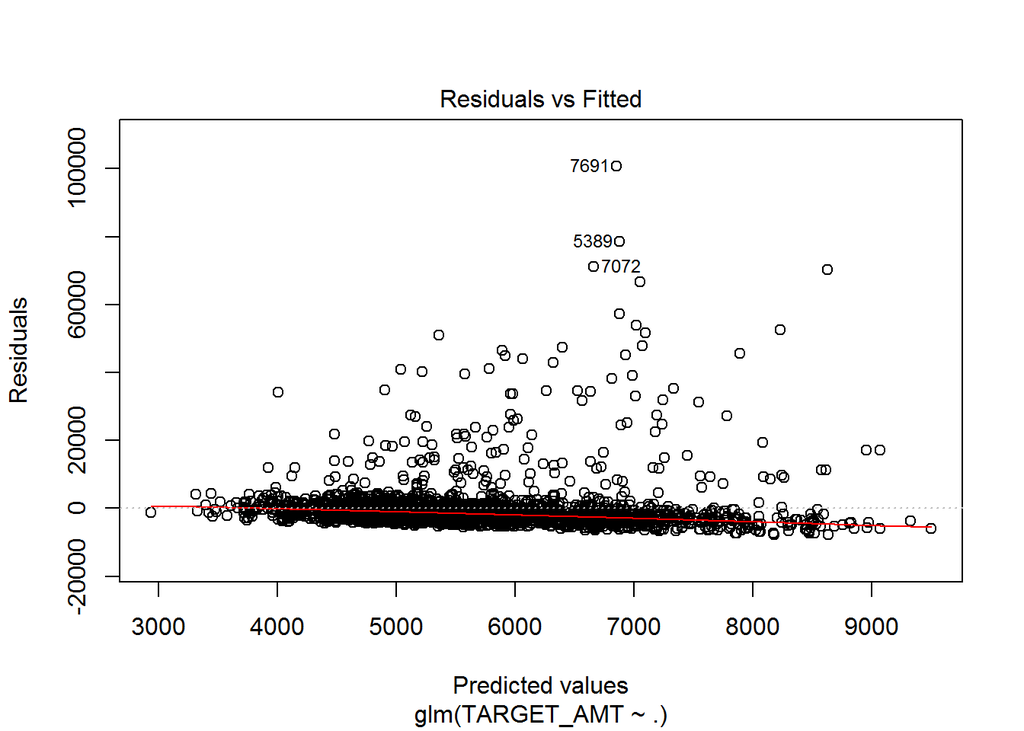

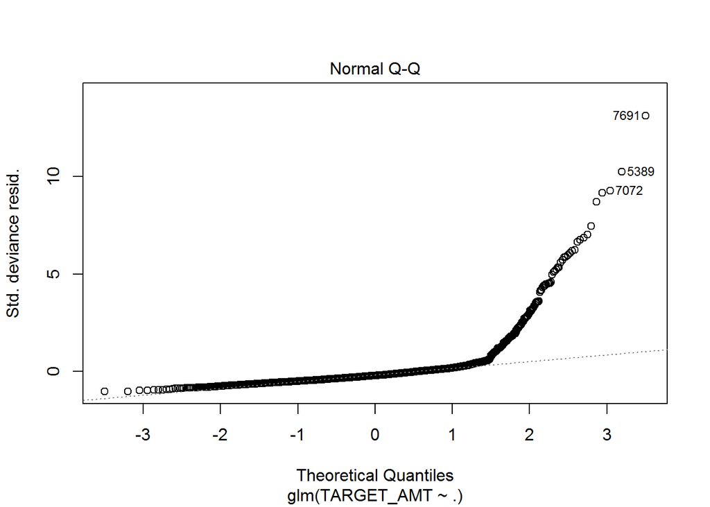

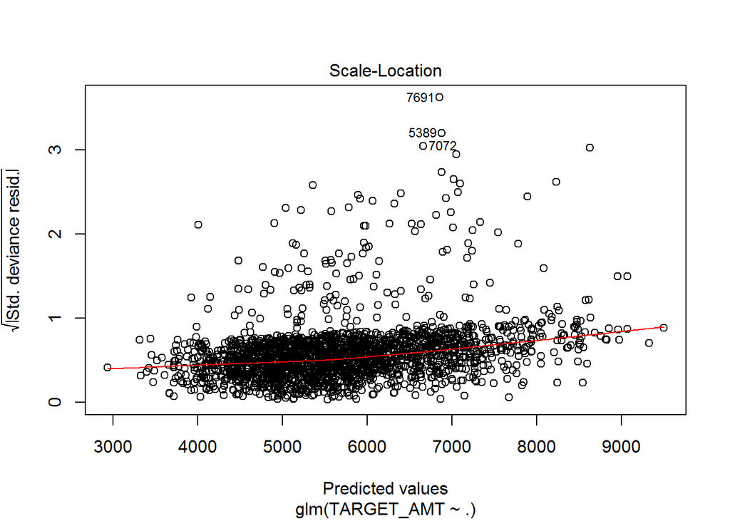

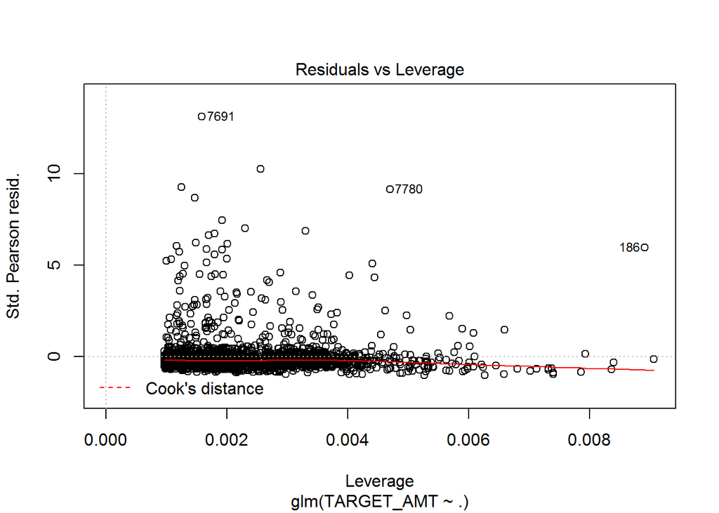

```r
plot(model3_amt)
```